# Outline of weeks 6-10

(this document may be updated some as the weeks proceed)

- Also see [guide to Alex Holcombe and his lectures](https://canvas.sydney.edu.au/courses/72032/pages/guide-to-weeks-7-13)

## Tutorials

Week 7 tutorial: Causal models, scientific studies, and confounds

Week 8 tutorial: Necessary and sufficient, if-then, and only-if [explained by Khan academy](https://www.khanacademy.org/test-prep/lsat/lsat-lessons/logic-toolbox-new/a/logic-toolbox--article--if-x-then-y--sufficiency-and-necessity) and [by Carneades](https://www.youtube.com/watch?v=ibjL90iY1d0)

Week 9 tutorial: Deductive and inductive arguments, suppositionally inescapable, inescapable, suppositionally strong, and strong.

Week 10 tutorial: Implicit premises, inductive arguments, identifying conclusions in real-world arguments

## Topics each week

Week 6: Stats and studies: Correlation and causation

- Correlation and causation intro
  - Learning objectives:
    - Understand and apply three causal models to explaining correlations
    - Know the term “spurious correlation”
- Where does data come from?
- Understanding correlation more deeply
  - Correlation of X with Y same as Y with X
  - Measurement and correlation
    - Correlation not affected by changes in units (as long as the unit conversion is linear: involves only multiplication and addition/subtraction)
  - When linear regression is not appropriate: [COVID-19 interactive lesson](https://alexholcombe.shinyapps.io/COVID19questions/)
- Three causal models
  - X causes Y; Y causes X; A third variable causes both
  - The third-cause fallacy
- A causal model can be at any level of detail
- Explanatory, Outcome, and Nuisance variables
  - IV (an explanatory variable in an experiment) and DV (an outcome variable in an experiment). Bruce slide:

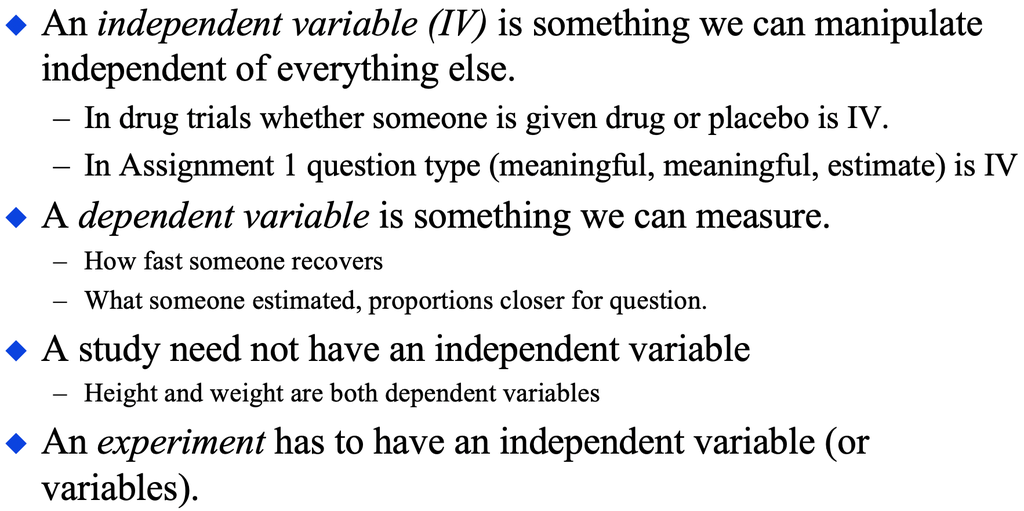

  - [Nuisance variable](https://dictionary.apa.org/nuisance-variable)
    - Is not different, on average, for the different levels of the variable we are interested in (BE CAREFUL, some sources online give a different definition)
  - [Confound](https://www.students4bestevidence.net/blog/2018/10/01/a-beginners-guide-to-confounding/) variables
    - Is different for the different levels of the variable we are interested in.
    - Bruce slide:

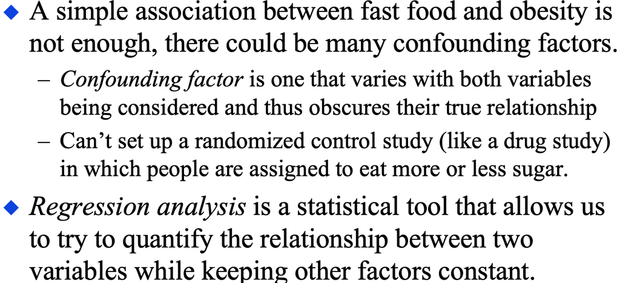

  - Can you distinguish between confounds and nuisance variables?
  - Random assignment
    - Bruce said:

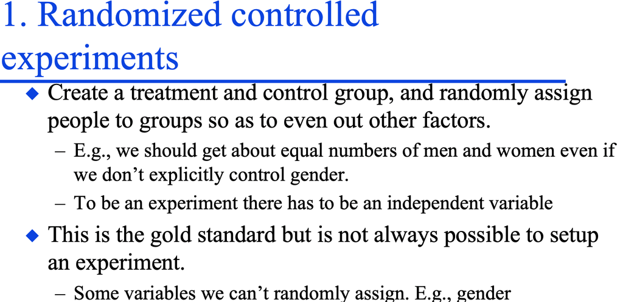

- Randomisation and control group
  - Bruce said

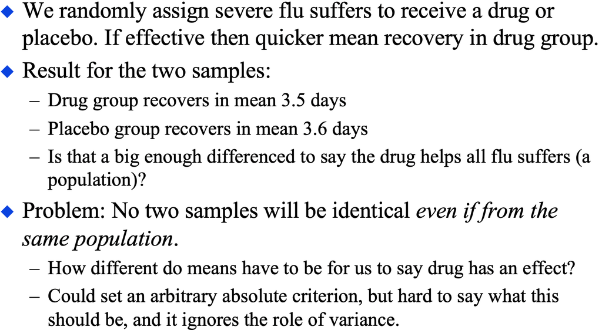

- Time as a third variable
  - Relationship between many observed variables, such as pirates and high average temperature, is confounded by time.
  - Time: Post hoc ergo propter hoc (After this therefore because of this) fallacy

Week 7

- Dichotomous correlation
  - dichotomous variables and correlation
  - Contingency tables
  - Later you will see the link to arguments and logic
- 4 kinds of control
  - Statistical adjustment - [controlling for](https://alexholcombe.github.io/teachingATHK/readings/controllingForVsControl.html) confounds
  - A controlled variable - matching
- Causal phrases versus correlational phrases (“Distinguish correlational and causal..” video on Canvas)

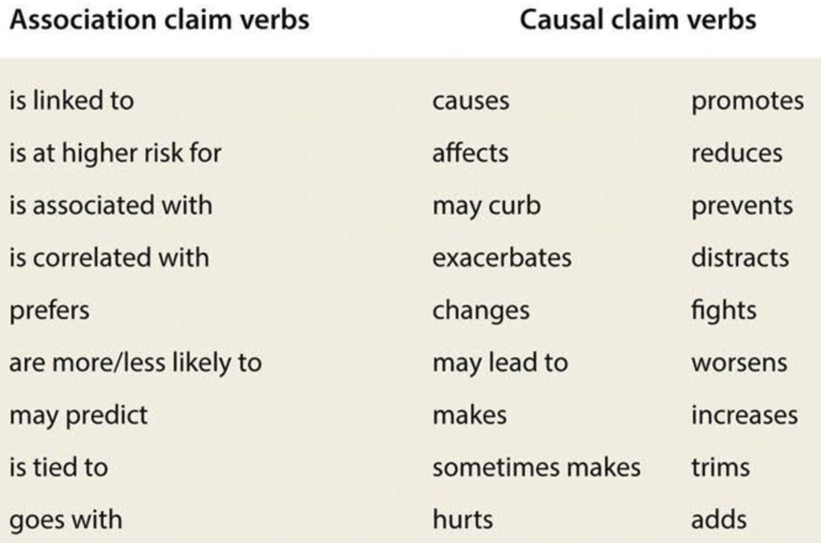

- Recognizing observational studies in the news
- Epidemiology (“Epidemiology and nutrition” video on Canvas)
  - Smoking has a big effect,
  - Nutrition effects are small
  - Many false positives, which we’ll explain later

Week 8

- Hypothesis testing review and extension
  - Review of hypothesis testing (recall tutorial week 4 and Bruce’s associated lecture)
  - Bruce slide:

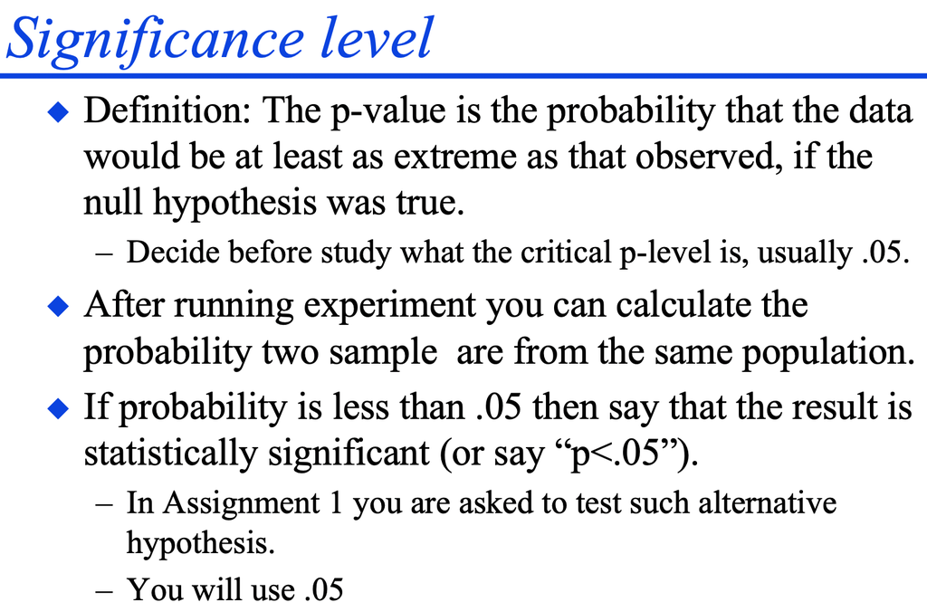

  - False positives, false negatives, true positives, true negatives
  - Hypothesis testing and medical testing
    - Sensitivity and specificity
- Why does the news have lots of false positives? (“Hypothesis testing review +” Canvas video)
  - Excess of statistical comparisons (“False positives and jelly beans” Canvas video)
  - More reasons for errors in science given later in the class, after logic and arguments

### Arguments and logic, Weeks 8-9

We’re going to go back and forth between bare-bones examples and arguments from the wild, giving you more and more tools to deal with the real-world ones.

A 9 min [intro video on youtube](https://www.youtube.com/watch?v=NKEhdsnKKHs), but it uses different terminology than we use in this unit.

- We need to know good reasons for believing things. Ideally,
  - Assumptions are true
  - Logic must be airtight (inescapable)
- Syllogisms introduction
  - Suppositionally inescapable; inescapable
- Truth contingency tables
- Necessary and sufficient
- Syllogisms
  - Suppositionally inescapable, inescapable, suppositionally solid, solid
- Towards real-world arguments
- The vegetarianism argument, student responses, and the difficulty of decoupling
- Redundant premises
- Implicit premises

### Arguments and reasoning in the wild, Week 10

- Polysyllogism
- Casting an argument - the we must bomb Iran argument
- Mindset for real-world (4 slides)
  - I will happily change, for I seek the truth - Aurelius.
  - Most arguments are people just trying to win - to get what they want. Persuasion.
  - But ideally you don’t just want to win, you actually want to learn and find things out.
- Loose language in the wild
  - hyperbole
  - principle of charity (related to steel man, discussed later)
- Induction and deduction
  - Process of elimination, Sherlock Holmes
  - Abduction